[O’Hara on GitHub](https://github.com/oharac)

# Map stressor extent to 95% volume contour

Compiled on Tue Jun 16 14:27:09 2020 by ohara

```r
knitr::opts_chunk$set(fig.width = 6, fig.height = 4, fig.path = 'Figs/',
                      echo = TRUE, message = FALSE, warning = FALSE)

library(raster)
# library(rgeos)
source('https://raw.githubusercontent.com/oharac/src/master/R/common.R')  ###
  ### includes library(tidyverse); library(stringr); dir_M points to ohi directory

source(here('common_fxns.R'))
source(here('_setup/rasterize_fxns.R'))
```

# 1 Summary

# 2 Data sources

Halpern et al. 2019

# 3 Methods

## 3.1 Make list of all stressor layers

Get all the stressor layers that have been aggregated to 10 km Mollweide.

```r
str_files_all <- list.files(file.path(dir_bd_anx, 'layers/stressors_10km'),
                        pattern = '.tif', full.names = TRUE)

str_df_all <- data.frame(file = str_files_all) %>%
  mutate(stressor = str_replace(basename(file), '_[0-9]{4}.+', ''),
         year = as.integer(str_extract(basename(file), '[0-9]{4}')))

str_years <- str_df_all %>%
  group_by(stressor) %>%
  summarize(year_min = min(year),
            year_max = max(year),
            range_03_13 = year_min <= 2003 & year_max >= 2013) %>%
  filter(range_03_13)

str_df <- str_df_all %>%
  filter(stressor %in% str_years$stressor) %>%
  filter(year >= 2003 & year <= 2013)
```

## 3.2 Loop over all stressors, process 95% volume contour

For each stressor, across the limited time series series, determine a threshold for the 95% volume contour. Use this threshold to clip values in all years of the stressor and save each year’s map as a raster. After determining the threshold, use `mclapply` for parallel calculations.

### 3.2.1 Determine thresholds for each stressor

Gather all rasters for a given stressor, arrange values from high to low, determine the 95% volume contour threshold. This will be based on values across ALL years in the range; so for stressors that increase over time, the threshold will most likely accept less than 95% in early years and more than 95% in later years. While we are at it, calculate 95% volume contour threshold for each year to examine changes over time. Save these values as a csv.

```r
reload <- FALSE
str_thresh_file <- here('_output', 'str_thresholds_95vc.csv')
# unlink(str_thresh_file)
if(!file.exists(str_thresh_file) | reload) {
  stressors <- str_df$stressor %>% unique() %>% sort()

  thresh_list <- parallel::mclapply(stressors, mc.cores = 4,
    FUN = function(str) {
      ### str <- stressors[14]
      str_fs <- str_df %>%
        filter(stressor == str) %>%
        .$file

      str_stack <- raster::stack(str_fs)

      thresh <- calc_cv_thresh(str_stack, pct = 0.95)
      tmp_df <- data.frame(
        stressor = str,
        thresh = thresh,
        timescale = '2003-2013')
      return(tmp_df)
    })

  thresh_annual_list <- parallel::mclapply(1:nrow(str_df), mc.cores = 12,
    FUN = function(i) { ### i <- 1
      str_year_df <- str_df[i, ]
      f <- str_year_df$file
      message('Processing ', basename(f))
      rast <- raster(f)
      thresh <- calc_cv_thresh(rast, pct = 0.95)
      tmp_df <- data.frame(
        stressor = str_year_df$stressor,
        year = str_year_df$year,
        thresh = thresh,
        timescale = 'annual')
      return(tmp_df)
    })

  thresh_df <- bind_rows(thresh_list, thresh_annual_list)

  write_csv(thresh_df, str_thresh_file)
} else {
  message('File exists: ', str_thresh_file, '... skipping')
}
```

### 3.2.2 Plot stressor distributions

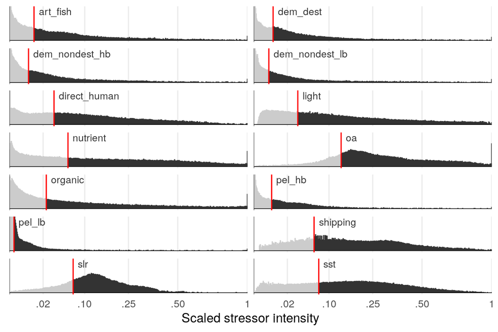

```r
thresh_df <- read_csv(str_thresh_file) %>%
  filter(timescale == '2003-2013') %>%
  select(stressor, thresh)

str_vals_file <- file.path(dir_bd_anx, 'fig_data/str_thresh_vals.csv')
# unlink(str_vals_file)
if(!file.exists(str_vals_file) | reload) {

  stressors <- thresh_df$stressor %>% unique() %>% sort()

  str_vals_list <- parallel::mclapply(stressors, mc.cores = 4,
    FUN = function(str) {
      ### str <- stressors[1]
      str_fs <- str_df %>%
        filter(stressor == str) %>%
        .$file

      str_stack <- raster::stack(str_fs)
      vals_all <- values(str_stack)
      vals_na_rm <- vals_all[!is.na(vals_all)]
      val_vec <- vals_na_rm[vals_na_rm > 0]

      max_n <- 1e5
      if(length(val_vec) > max_n) {
        val_vec <- sample(val_vec, max_n)
      }

      tmp_df <- data.frame(stressor = str,
                           val = val_vec)
      return(tmp_df)
    })

  str_vals_df <- bind_rows(str_vals_list)

  write_csv(str_vals_df, str_vals_file)
} else {
  message('File exists: ', str_vals_file)
}

str_vals_df <- read_csv(str_vals_file)

n_bins <- 500

plot_df_1 <- str_vals_df %>%
  sample_n(1e5) %>%
  left_join(thresh_df, by = 'stressor') %>%
  mutate(below_thresh = ifelse(val < thresh, TRUE, FALSE)) %>%
  # group_by(stressor) %>%
  # arrange(val) %>%
  # mutate(cum_val_pct = cumsum(val) / sum(val)) %>%
  ungroup() # %>%
  # filter(stressor == 'art_fish')

plot_df <- str_vals_df %>%
  sample_n(1e6) %>%
  mutate(sqrt_val = sqrt(val),
         b = cut(sqrt_val, n_bins)) %>%
  group_by(stressor, b) %>%
  summarize(n = n()) %>%
  ungroup() %>%
  left_join(thresh_df, by = 'stressor') %>%
  mutate(x = as.numeric(str_replace_all(b, '.+,|]', '')),
         v = x^2,
         below_thresh = ifelse(v < thresh, TRUE, FALSE))

y_pos <- sqrt(max(plot_df$n)) / 4
x_lbls <- c('.02', '.10', '.25', '.50', '1')
x_brks <- as.numeric(x_lbls)


ggplot(plot_df) +
  geom_linerange(aes(x = x, ymax = sqrt(n),
                     color = below_thresh),
                 ymin = 0,
                 size = .5,
                 show.legend = FALSE) +
  geom_vline(xintercept = 0, color = 'black', size = .25) +
  geom_hline(yintercept = 0, color = 'black', size = .25) +
  geom_vline(aes(xintercept = sqrt(thresh)), color = 'red', size = .5) +
  scale_color_manual(values = c('grey20', 'grey80')) +
  geom_text(data = thresh_df,
            aes(label = stressor,
                x = sqrt(thresh)),
            y = y_pos,
            color = 'grey20', size = 3,
            nudge_x = .02, nudge_y = -.02,
            hjust = 0, vjust = 1) +
  # geom_hline(yintercept = 0.05) +
  coord_cartesian(ylim = c(0, y_pos)) +
  scale_x_continuous(breaks = sqrt(x_brks),
                     labels = x_lbls,
                     expand = c(0, 0)) +
  facet_wrap( ~ stressor,
              # scales = 'free_y',
              ncol = 2) +
  theme_minimal() +
  theme(axis.title.y = element_blank(),
        axis.text.y = element_blank(),
        panel.grid.minor = element_blank(),
        panel.grid.major.y = element_blank(),
        strip.background = element_blank(),
        strip.text.x = element_blank()) +
  labs(x = 'Scaled stressor intensity')
```

### 3.2.3 Clip individual stressor maps to 95% volume contour

Using the threshold across the range of years (2003-2013), clip each stressor map to values greater than the threshold.

```r
reload <- FALSE

thresh_df <- read_csv(str_thresh_file)

stressors <- str_df$stressor %>% unique() %>% sort()

outfile_dir <- file.path(dir_bd_anx, 'layers/stressors_10km_95vc')
# unlink(file.path(outfile_dir, '*.*'))
# unlink(file.path(outfile_dir, 'sst*.*'))

tmp <- parallel::mclapply(stressors, mc.cores = 8,
  FUN = function(str) { ### str <- stressors[1]
    message('Processing ', str)

    ### get the raw raster file(s) for this stressor
    str_year_df <- str_df %>%
      filter(stressor == str)
    f <- str_year_df$file

    ### get the threshold for this stressor from the saved threshold df
    thresh_all_yrs <- thresh_df %>%
      filter(timescale == '2003-2013') %>%
      filter(stressor == str) %>%
      .$thresh

    ### set up filename(s) for the output(s)
    new_files <- str_replace(basename(f), '.tif', '_95vc.tif') %>%
      str_replace('_rescaled', '')
    outfiles <- file.path(outfile_dir, new_files)

    if(any(!file.exists(outfiles)) | reload) {
      ### gather all rasters for this stressor into a stack
      str_stack <- raster::stack(f)
      str_stack_95vc <- map_contour_volume(str_stack, thresh = thresh_all_yrs)
      writeRaster(str_stack_95vc, outfiles, bylayer = TRUE, overwrite = TRUE)
    } else {
      message('95% volume contour files exist for stressor: ', str, '... skipping!')
    }
  })
```

## 3.3 Map results

Map the 95% volume contour map against the full map - setting values for the full map to one (normalized) value and the values for the 95% volume contour to another to show contrast. Because all the 95% volume contour cells are within the full raster, we can simply plot it in a different color on top of the full raster.

Here, green is the raster condensed to the 95% volume contour while dark red is the full raster.

```r
library(animation)

make_overlap_gifs <- function(stack_full, stack_95vc, filename, layer_names = NULL) {
  capture.output({
    saveGIF({
      for(i in 1:nlayers(stack_full)){
        plot(stack_full[[i]],
             col = 'darkred',
             legend = FALSE,
             axes = FALSE,
             main = layer_names[i])
        plot(stack_95vc[[i]],
             col = 'green', axes = FALSE, add = TRUE)
      }},
      interval = 0.5, movie.name = filename,
      ani.width = 700, ani.height = 420)
  })

  return(invisible(NULL))
}
```

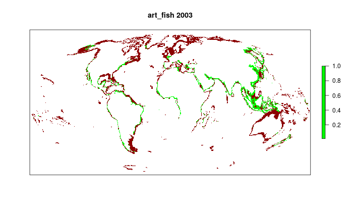

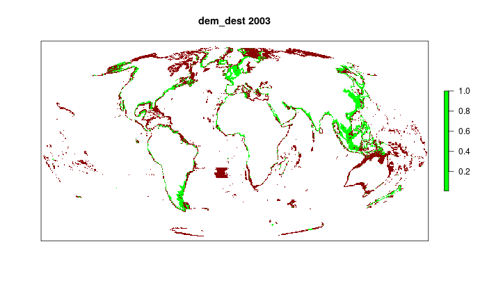

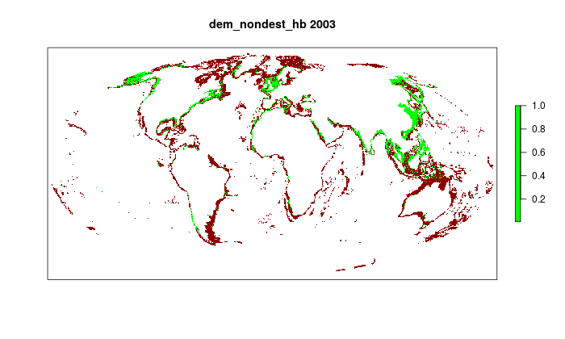

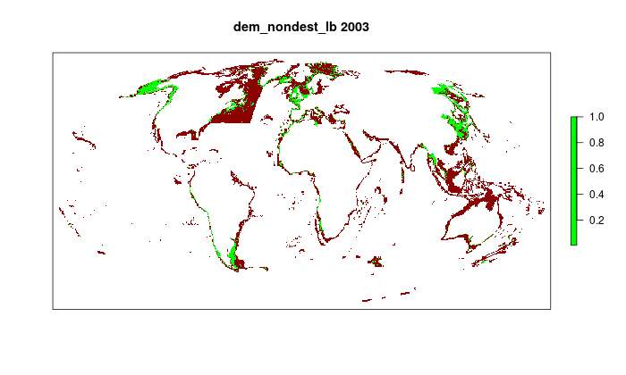

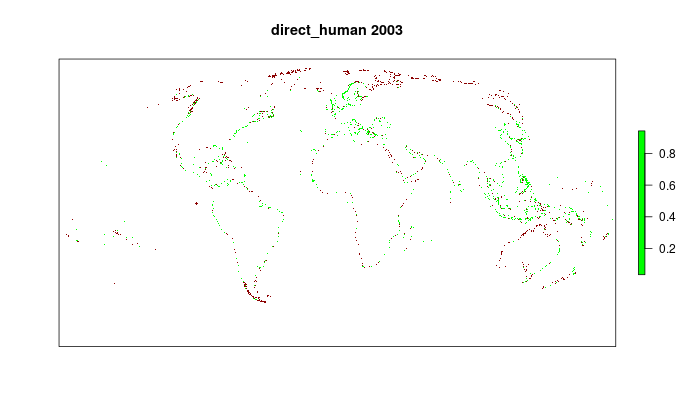

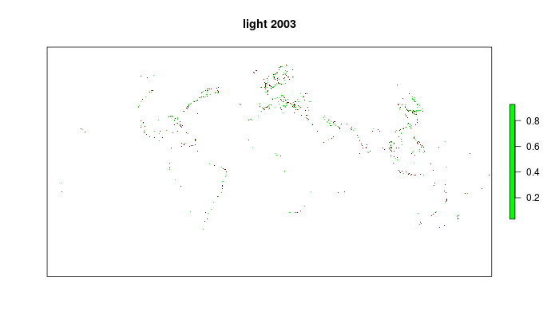

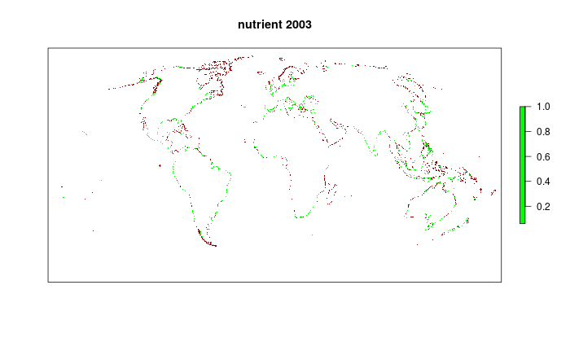

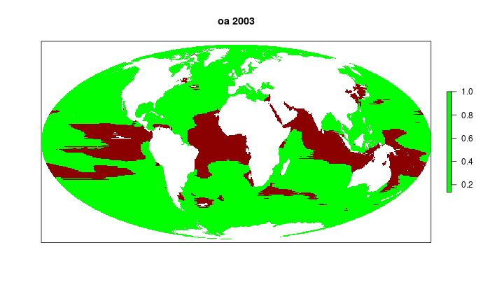

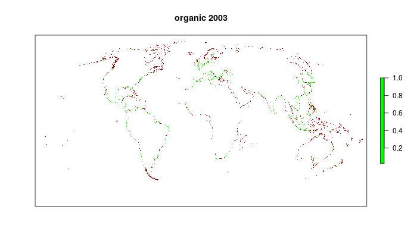

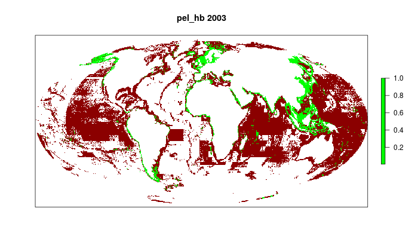

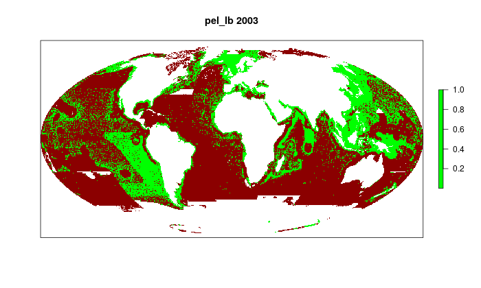

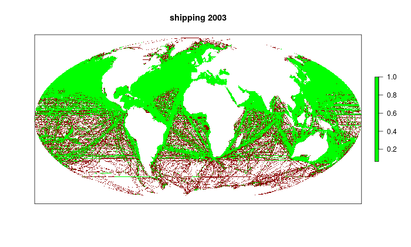

[2 more figures not shown]

```r
str_95vc_files <- list.files(file.path(dir_bd_anx, 'layers/stressors_10km_95vc'),
                             full.names = TRUE)
str_full_files <- str_replace_all(str_95vc_files, '_95vc', '') %>%
  str_replace_all('mol10km.tif', 'rescaled_mol10km.tif')
years <- 2003:2013

str_map_df <- data.frame(str_full_file = str_full_files,
                         str_95vc_file = str_95vc_files) %>%
  mutate(str  = str_replace(basename(str_full_file), '_[0-9].+', ''),
         year = str_extract(basename(str_full_file), '[0-9]{4}') %>%
           as.integer()) %>%
  group_by(str) %>%
  filter(min(year) <= 2003 & max(year) >= 2013) %>%
  ungroup() %>%
  filter(year %in% years)

stressors <- str_map_df$str %>% unique()

for(stressor in stressors) { ### stressor <- stressors[1]
  ### Animate the results
  gif_file <- here('_setup', sprintf('figs/str_95vc_movie_%s.gif', stressor))

  maps_df <- str_map_df %>%
    filter(str == stressor)

  if(!file.exists(gif_file)) {
    message('creating ', gif_file)
    stack_full <- stack(maps_df$str_full_file)
    values(stack_full)[values(stack_full) == 0] <- NA
    stack_95vc <- stack(maps_df$str_95vc_file)

    make_overlap_gifs(stack_full, stack_95vc,
              filename = gif_file,
              layer_names = paste(stressor, years))
  }

  cat(sprintf('![](%s)', gif_file))
}
```